# Week 6 Homework Rmarkdown

Statistical Analysis

Week 6

# 1 Tokyo Olympics 2021 Medal Data

Read in the Tokyo 2021 olympic medal data from github

```r
medal_data <- vroom("https://raw.githubusercontent.com/chrit88/Bioinformatics_data/master/Workshop%205/Tokyo%202021%20medals.csv")
```

```r
medal_data
```

```
## # A tibble: 89 x 4
##    Country            Gold Silver Bronze
##    <chr>             <dbl>  <dbl>  <dbl>
##  1 United States        39     41     33
##  2 Republic of China    38     32     18
##  3 Japan                27     14     17
##  4 Great Britain        22     21     22
##  5 Russia               20     28     23
##  6 Australia            17      7     22
##  7 Germany              10     11     16
##  8 Italy                10     10     20
##  9 France               10     12     11
## 10 Netherlands          10     12     14
## # ... with 79 more rows
```

Add GDP column for all countries by calling `library(wbstats)`

Extract GDP data for all countries for 2020 (no 2021 data)

```r
all_GDP_data <- wb_data(indicator = "NY.GDP.MKTP.CD",
                        start_date = 2020,
                        end_date = 2020)
all_GDP_data
```

```
## # A tibble: 217 x 9
##    iso2c iso3c country             date NY.GDP.MKTP.CD unit  obs_status footnote
##    <chr> <chr> <chr>              <dbl>          <dbl> <chr> <chr>      <chr>
##  1 AW    ABW   Aruba               2020            NA  <NA>  <NA>       <NA>
##  2 AF    AFG   Afghanistan         2020   19807067268. <NA>  <NA>       <NA>
##  3 AO    AGO   Angola              2020   62306913444. <NA>  <NA>       <NA>
##  4 AL    ALB   Albania             2020   14799615097. <NA>  <NA>       <NA>
##  5 AD    AND   Andorra             2020            NA  <NA>  <NA>       <NA>
##  6 AE    ARE   United Arab Emira~  2020            NA  <NA>  <NA>       <NA>
##  7 AR    ARG   Argentina           2020  383066977654. <NA>  <NA>       <NA>
##  8 AM    ARM   Armenia             2020   12645459214. <NA>  <NA>       <NA>
##  9 AS    ASM   American Samoa      2020            NA  <NA>  <NA>       <NA>
## 10 AG    ATG   Antigua and Barbu~  2020    1415059259. <NA>  <NA>       <NA>
## # ... with 207 more rows, and 1 more variable: last_updated <date>
```

Rename all_GDP_data column 5 to GDP

```r
names(all_GDP_data)[5] <- "GDP"
all_GDP_data
```

```
## # A tibble: 217 x 9
##    iso2c iso3c country     date       GDP unit  obs_status footnote last_updated
##    <chr> <chr> <chr>      <dbl>     <dbl> <chr> <chr>      <chr>    <date>
##  1 AW    ABW   Aruba       2020  NA       <NA>  <NA>       <NA>     2021-10-28
##  2 AF    AFG   Afghanist~  2020   1.98e10 <NA>  <NA>       <NA>     2021-10-28
##  3 AO    AGO   Angola      2020   6.23e10 <NA>  <NA>       <NA>     2021-10-28
##  4 AL    ALB   Albania     2020   1.48e10 <NA>  <NA>       <NA>     2021-10-28
##  5 AD    AND   Andorra     2020  NA       <NA>  <NA>       <NA>     2021-10-28
##  6 AE    ARE   United Ar~  2020  NA       <NA>  <NA>       <NA>     2021-10-28
##  7 AR    ARG   Argentina   2020   3.83e11 <NA>  <NA>       <NA>     2021-10-28
##  8 AM    ARM   Armenia     2020   1.26e10 <NA>  <NA>       <NA>     2021-10-28
##  9 AS    ASM   American ~  2020  NA       <NA>  <NA>       <NA>     2021-10-28
## 10 AG    ATG   Antigua a~  2020   1.42e 9 <NA>  <NA>       <NA>     2021-10-28
## # ... with 207 more rows
```

Ensure all countries are identified as the correct country before merging with world data by calling `library(countrycode)`

Add a column to medal data containing the country code

```r
medal_data$code <- countrycode(medal_data$Country,
                               origin = "country.name",
                               destination = "iso3c")
medal_data
```

```
## # A tibble: 89 x 5
##    Country            Gold Silver Bronze code
##    <chr>             <dbl>  <dbl>  <dbl> <chr>
##  1 United States        39     41     33 USA
##  2 Republic of China    38     32     18 TWN
##  3 Japan                27     14     17 JPN
##  4 Great Britain        22     21     22 GBR
##  5 Russia               20     28     23 RUS
##  6 Australia            17      7     22 AUS
##  7 Germany              10     11     16 DEU
##  8 Italy                10     10     20 ITA
##  9 France               10     12     11 FRA
## 10 Netherlands          10     12     14 NLD
## # ... with 79 more rows
```

Look at head of new dataset

```r
head(medal_data, 3)
```

```
## # A tibble: 3 x 5
##   Country            Gold Silver Bronze code
##   <chr>             <dbl>  <dbl>  <dbl> <chr>
## 1 United States        39     41     33 USA
## 2 Republic of China    38     32     18 TWN
## 3 Japan                27     14     17 JPN
```

Correct China

```r
medal_data$code[2] <- "CHN"
head(medal_data, 3)
```

```
## # A tibble: 3 x 5
##   Country            Gold Silver Bronze code
##   <chr>             <dbl>  <dbl>  <dbl> <chr>
## 1 United States        39     41     33 USA
## 2 Republic of China    38     32     18 CHN
## 3 Japan                27     14     17 JPN
```

Select just iso3c and GDP column Use dplyr::select as conflict with MASS package

```r
head(all_GDP_data %>% dplyr::select( iso3c, GDP ))
```

```
## # A tibble: 6 x 2
##   iso3c          GDP
##   <chr>        <dbl>
## 1 ABW            NA
## 2 AFG   19807067268.
## 3 AGO   62306913444.
## 4 ALB   14799615097.
## 5 AND            NA
## 6 ARE            NA
```

Join two data sets

```r
medal_GDP <- left_join(medal_data,
                         all_GDP_data %>% dplyr::select(iso3c, GDP),
                         by = c("code" = "iso3c"))
medal_GDP
```

```
## # A tibble: 89 x 6
##    Country            Gold Silver Bronze code      GDP
##    <chr>             <dbl>  <dbl>  <dbl> <chr>   <dbl>
##  1 United States        39     41     33 USA   2.09e13
##  2 Republic of China    38     32     18 CHN   1.47e13
##  3 Japan                27     14     17 JPN   4.98e12
##  4 Great Britain        22     21     22 GBR   2.71e12
##  5 Russia               20     28     23 RUS   1.48e12
##  6 Australia            17      7     22 AUS   1.33e12
##  7 Germany              10     11     16 DEU   3.85e12
##  8 Italy                10     10     20 ITA   1.89e12
##  9 France               10     12     11 FRA   2.63e12
## 10 Netherlands          10     12     14 NLD   9.14e11
## # ... with 79 more rows
```

Drop rows with NA values

```r
medal_GDP <- medal_GDP %>% drop_na()
```

As gold medal frequency essentially determines table ranking, plot gold medals won against country GDP

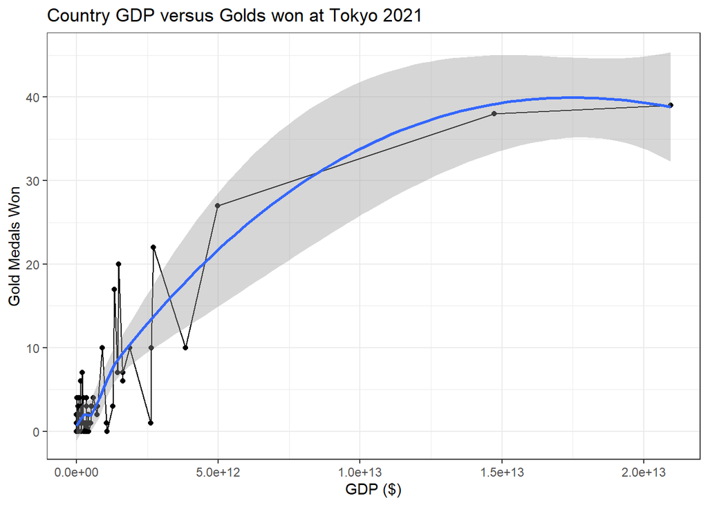

```r
p1 <- ggplot(medal_GDP, aes(x = GDP,
                             y = Gold)) +
  geom_point() +
  geom_line() +
  theme_bw() +
  ylab("Gold Medals Won") +
  xlab("GDP ($)")

p1 <- p1 + geom_smooth(method="loess")

p1 <- p1 + ggtitle("Country GDP versus Golds won at Tokyo 2021")
p1
```

Fit a glm()

```r
mod_gold_1 <- glm(Gold ~ GDP,
                  data = medal_GDP,
                  family = "gaussian")
mod_gold_1
```

```
##
## Call:  glm(formula = Gold ~ GDP, family = "gaussian", data = medal_GDP)
##
## Coefficients:
## (Intercept)          GDP
##   1.937e+00    2.196e-12
##
## Degrees of Freedom: 79 Total (i.e. Null);  78 Residual
## Null Deviance:       4384
## Residual Deviance: 1185  AIC: 448.7
```

Plot diagnostic plots

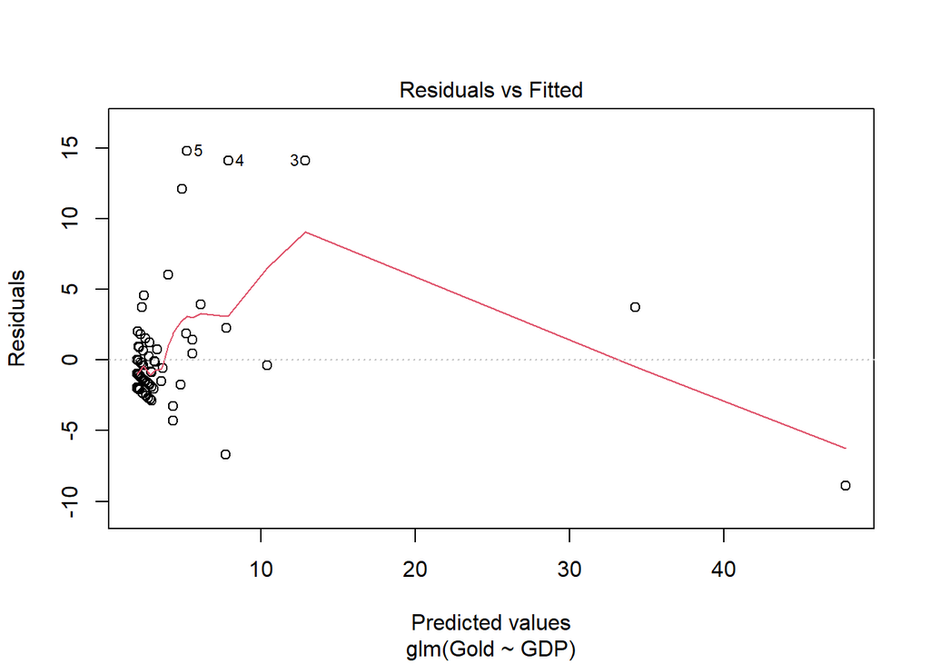

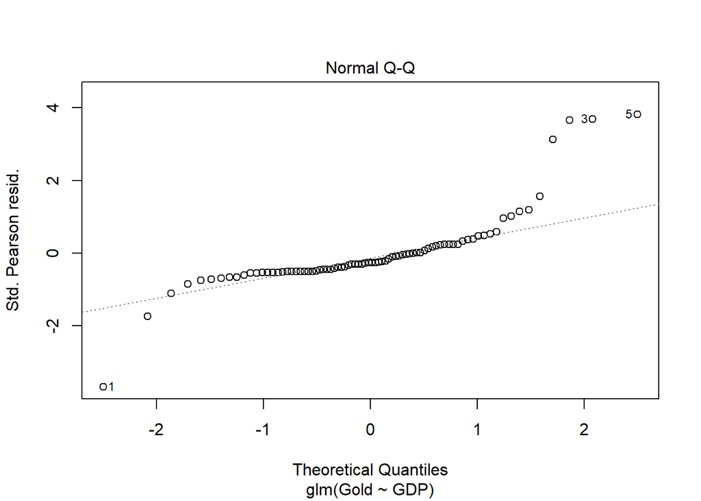

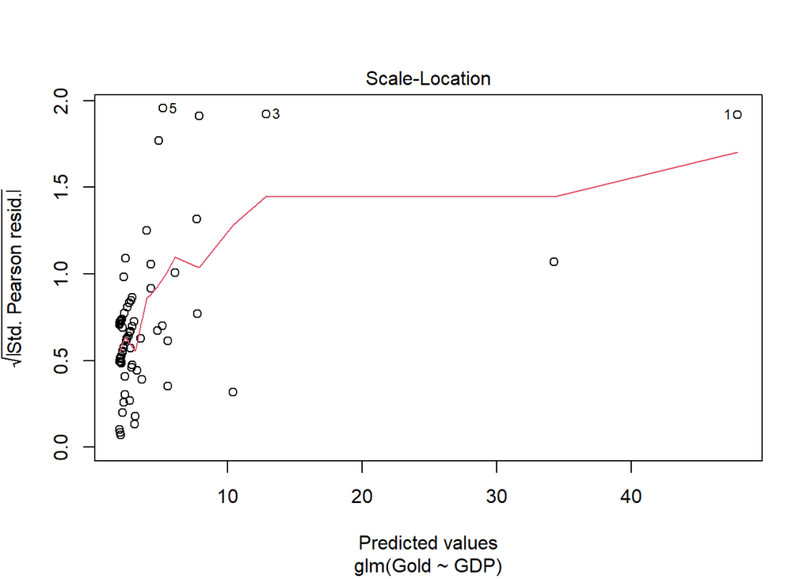

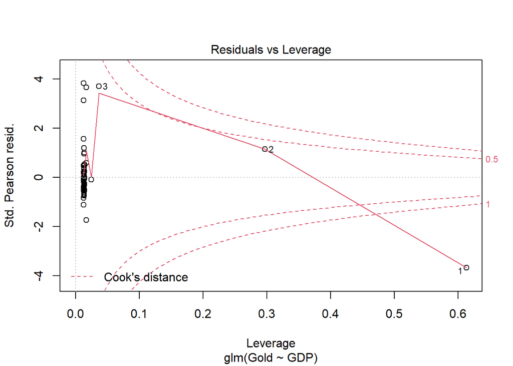

```r
plot(mod_gold_1)
```

Summarise the model outputs

```r
summary(mod_gold_1)
```

```
##
## Call:
## glm(formula = Gold ~ GDP, family = "gaussian", data = medal_GDP)
##
## Deviance Residuals:
##     Min       1Q   Median       3Q      Max
## -8.9159  -1.9630  -1.0165   0.9179  14.8054
##
## Coefficients:
##              Estimate Std. Error t value Pr(>|t|)
## (Intercept) 1.937e+00  4.603e-01   4.207 6.84e-05 ***
## GDP         2.196e-12  1.513e-13  14.512  < 2e-16 ***
## ---
## Signif. codes:  0 '***' 0.001 '**' 0.01 '*' 0.05 '.' 0.1 ' ' 1
##
## (Dispersion parameter for gaussian family taken to be 15.19157)
##
##     Null deviance: 4384.4  on 79  degrees of freedom
## Residual deviance: 1184.9  on 78  degrees of freedom
## AIC: 448.66
##
## Number of Fisher Scoring iterations: 2
```

Significant impact of GDP on gold medals won: higher GDP correlates with higher gold medal count.

Fit a glm with a poisson distribution to see if better model fit.

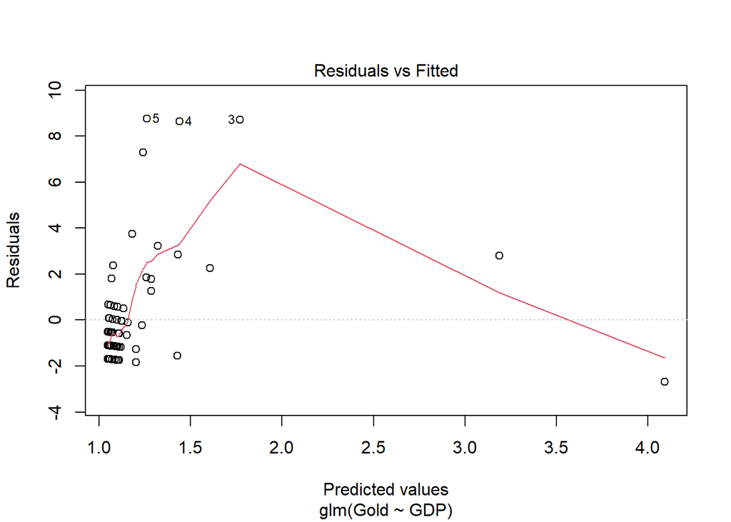

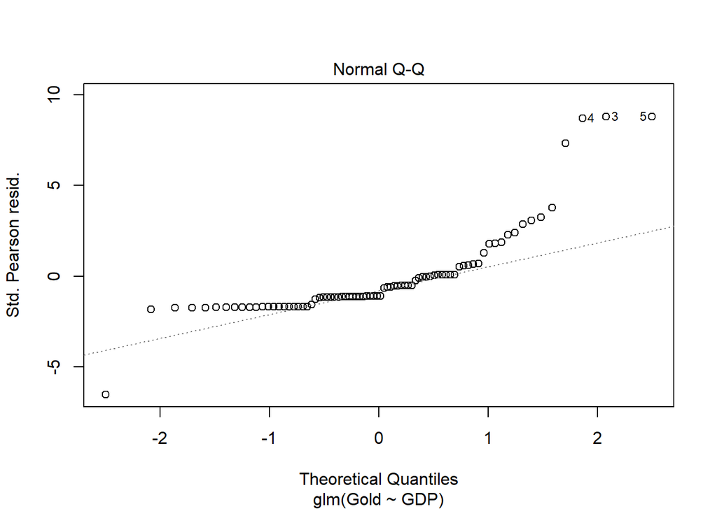

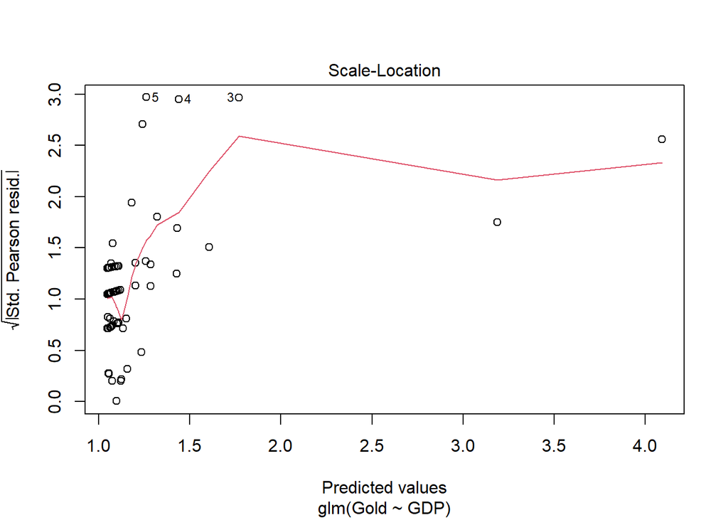

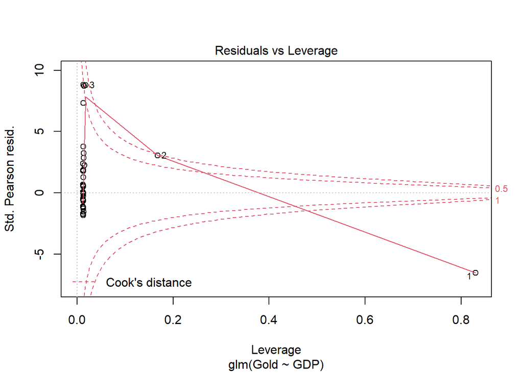

```r
mod_gold_2 <- glm(Gold ~ GDP,
                  data = medal_GDP,
                  family = "poisson")
plot(mod_gold_2)
```

Not good fit as normal Q-Q plot very ill-fitting plus points are outside 1 lines on residuals vs leverage graph

# 2 Iris flower data

Load the iris data set

```r
data("iris")
```

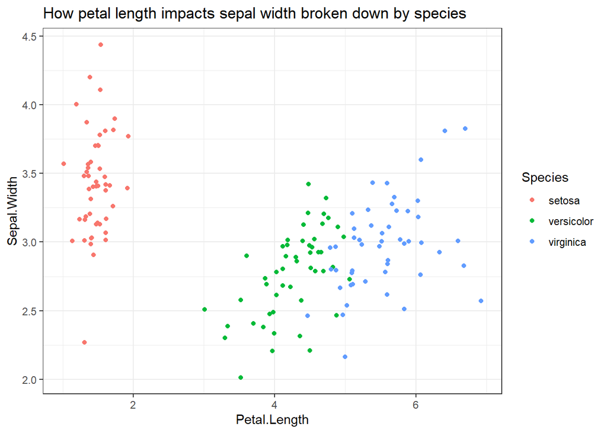

```r
ggplot( iris, aes( x = Petal.Length, y = Sepal.Width)) +
  geom_jitter(aes(col = Species)) +
  theme_bw()+
  ggtitle("How petal length impacts sepal width broken down by species")
```

Fit a glm()

```r
mod_petal <- glm(Sepal.Width ~ Petal.Length*Species,
                data = iris,
                family = "gaussian")
mod_petal
```

```
##
## Call:  glm(formula = Sepal.Width ~ Petal.Length * Species, family = "gaussian",
##     data = iris)
##
## Coefficients:
##                    (Intercept)                    Petal.Length
##                        2.86093                         0.38787
##              Speciesversicolor                Speciesvirginica
##                       -1.68548                        -1.18803
## Petal.Length:Speciesversicolor   Petal.Length:Speciesvirginica
##                       -0.01357                        -0.15353
##
## Degrees of Freedom: 149 Total (i.e. Null);  144 Residual
## Null Deviance:       28.31
## Residual Deviance: 14.4  AIC: 88.21
```

Plot model

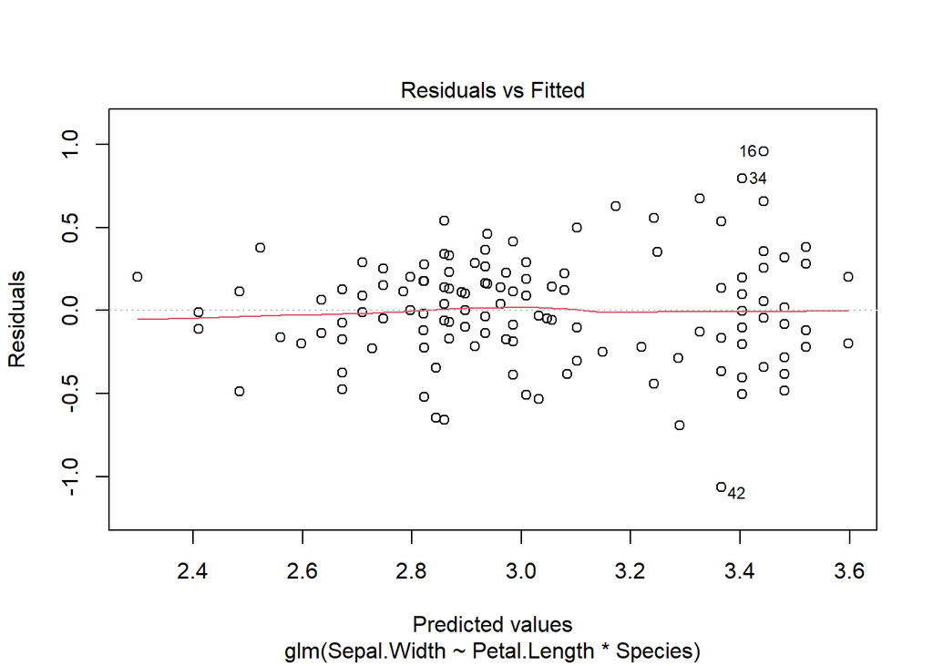

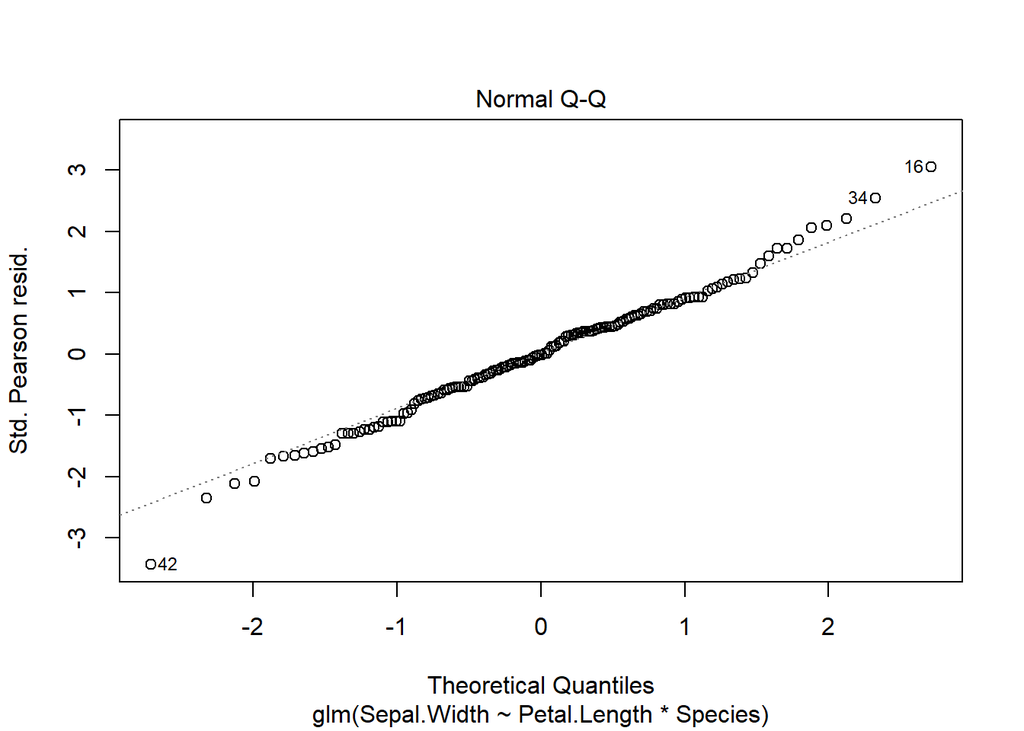

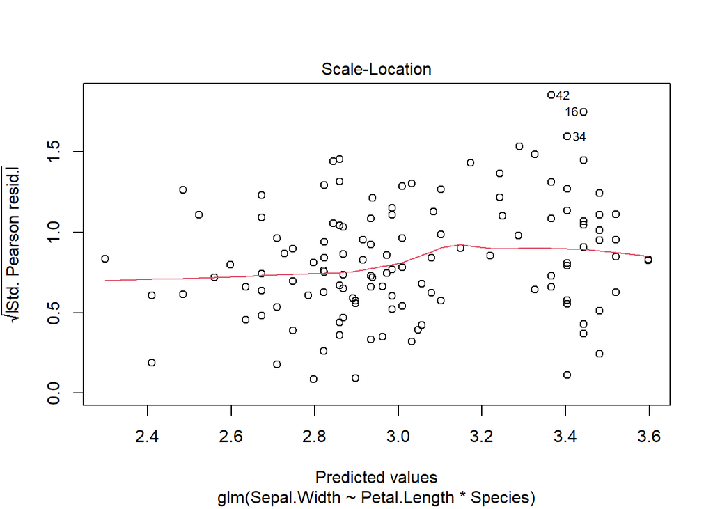

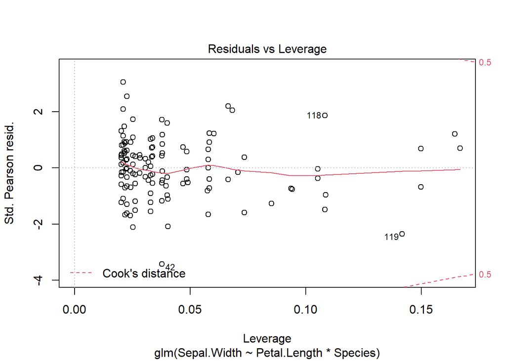

```r
plot(mod_petal)
```

Summarise model outputs

```r
summary(mod_petal)
```

```
##
## Call:
## glm(formula = Sepal.Width ~ Petal.Length * Species, family = "gaussian",
##     data = iris)
##
## Deviance Residuals:
##      Min        1Q    Median        3Q       Max
## -1.06516  -0.18525  -0.00395   0.19605   0.95726
##
## Coefficients:
##                                Estimate Std. Error t value Pr(>|t|)
## (Intercept)                     2.86093    0.38299   7.470 7.09e-12 ***
## Petal.Length                    0.38787    0.26017   1.491  0.13819
## Speciesversicolor              -1.68548    0.56254  -2.996  0.00322 **
## Speciesvirginica               -1.18803    0.59605  -1.993  0.04813 *
## Petal.Length:Speciesversicolor -0.01357    0.27737  -0.049  0.96106
## Petal.Length:Speciesvirginica  -0.15353    0.27274  -0.563  0.57438
## ---
## Signif. codes:  0 '***' 0.001 '**' 0.01 '*' 0.05 '.' 0.1 ' ' 1
##
## (Dispersion parameter for gaussian family taken to be 0.1000283)
##
##     Null deviance: 28.307  on 149  degrees of freedom
## Residual deviance: 14.404  on 144  degrees of freedom
## AIC: 88.213
##
## Number of Fisher Scoring iterations: 2
```

```r
log_sepal_width <- log(iris$Sepal.Width)
```

Add log_sepal_width column to dataframe

```r
iris <- iris %>% mutate(log_sepal_width)
```

[figure not shown]

```r
ggplot( iris, aes( x = Petal.Length, y = log_sepal_width)) +
  geom_jitter(aes(col = Species)) +
  theme_bw()+
  ggtitle("How petal length impacts the log10 of sepal width broken down by species")
```

Fit a glm()

```r
mod_log <- glm(log_sepal_width ~ Petal.Length*Species,
                 data = iris,
                 family = "gaussian")
mod_log
```

```
##
## Call:  glm(formula = log_sepal_width ~ Petal.Length * Species, family = "gaussian",
##     data = iris)
##
## Coefficients:
##                    (Intercept)                    Petal.Length
##                        1.04596                         0.12305
##              Speciesversicolor                Speciesvirginica
##                       -0.62616                        -0.38719
## Petal.Length:Speciesversicolor   Petal.Length:Speciesvirginica
##                        0.01603                        -0.04643
##
## Degrees of Freedom: 149 Total (i.e. Null);  144 Residual
## Null Deviance:       3.049
## Residual Deviance: 1.548     AIC: -246.3
```

Plot model

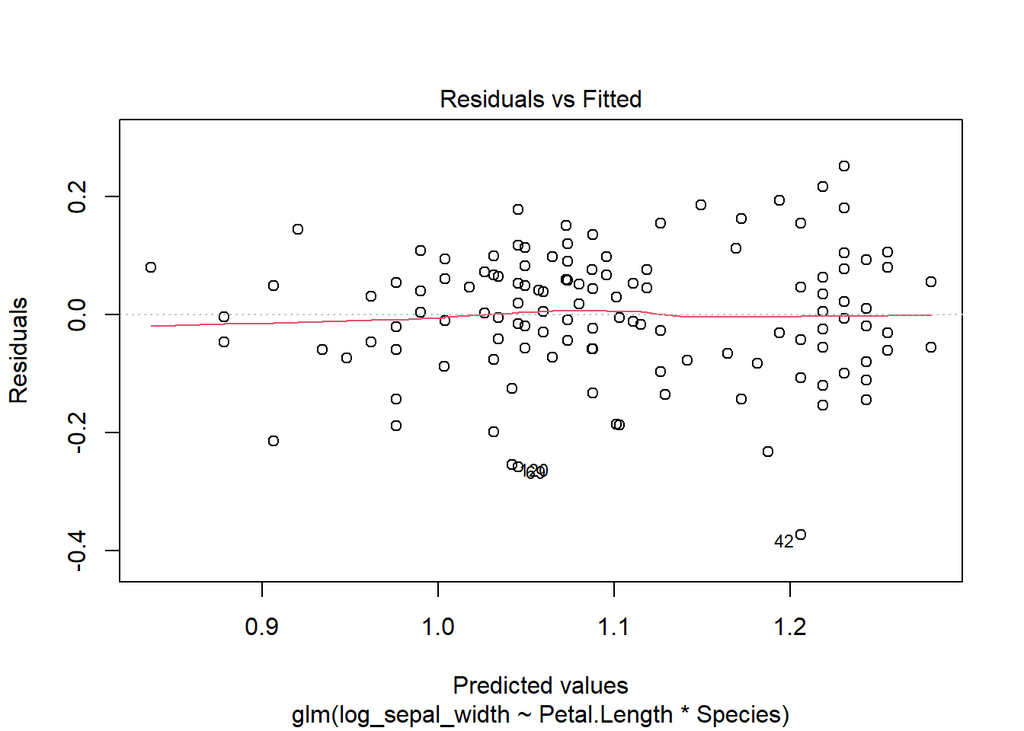

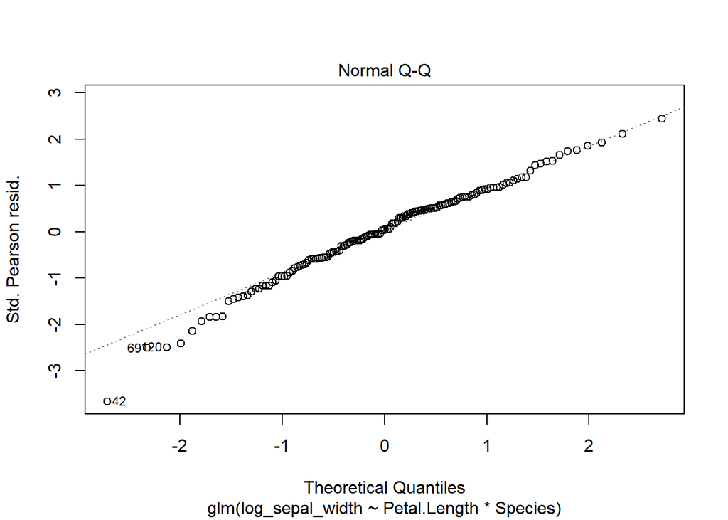

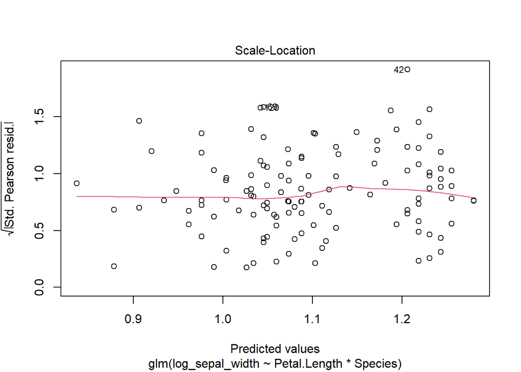

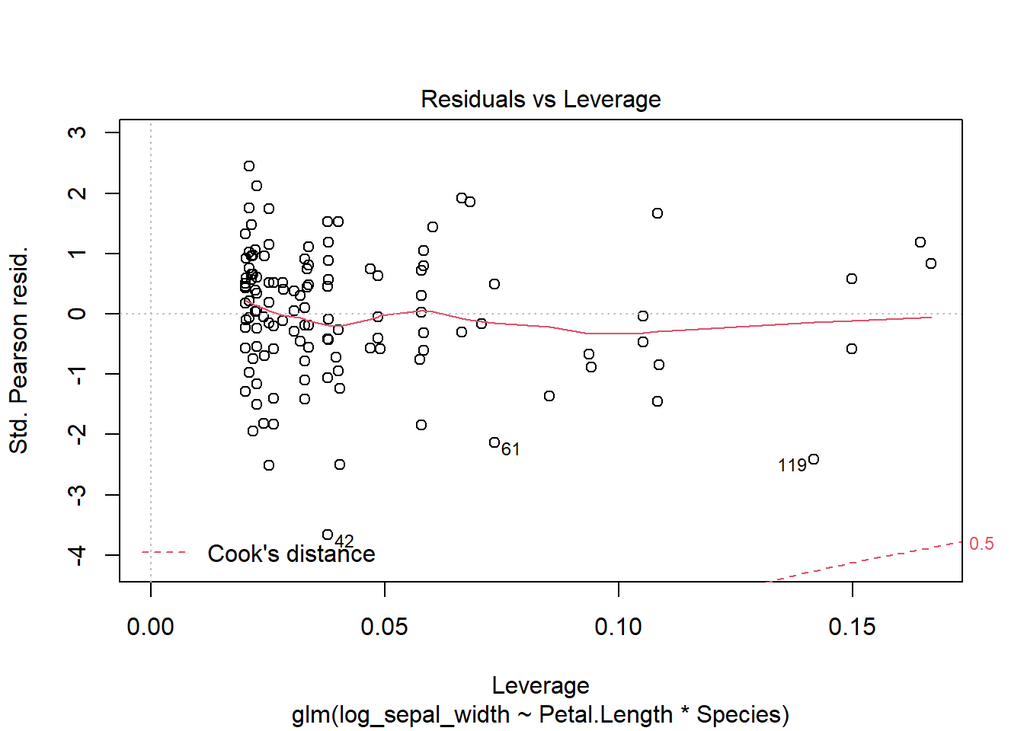

```r
plot(mod_log)
```

Summarise model outputs

```r
summary(mod_log)
```

```
##
## Call:
## glm(formula = log_sepal_width ~ Petal.Length * Species, family = "gaussian",
##     data = iris)
##
## Deviance Residuals:
##      Min        1Q    Median        3Q       Max
## -0.37301  -0.05824   0.00418   0.06624   0.25107
##
## Coefficients:
##                                Estimate Std. Error t value Pr(>|t|)
## (Intercept)                     1.04596    0.12557   8.330 5.78e-14 ***
## Petal.Length                    0.12305    0.08530   1.443 0.151312
## Speciesversicolor              -0.62616    0.18444  -3.395 0.000887 ***
## Speciesvirginica               -0.38719    0.19542  -1.981 0.049458 *
## Petal.Length:Speciesversicolor  0.01603    0.09094   0.176 0.860315
## Petal.Length:Speciesvirginica  -0.04643    0.08942  -0.519 0.604435
## ---
## Signif. codes:  0 '***' 0.001 '**' 0.01 '*' 0.05 '.' 0.1 ' ' 1
##
## (Dispersion parameter for gaussian family taken to be 0.01075244)
##
##     Null deviance: 3.0486  on 149  degrees of freedom
## Residual deviance: 1.5484  on 144  degrees of freedom
## AIC: -246.34
##
## Number of Fisher Scoring iterations: 2
```

More significant than previous glm showing versicolor and and virginica affected by sepal width however no overall effect of petal.length.